# AML Rohit Assignment-4

ROHIT VURADI

2024-04-21

# Introduction

This demonstrates how to perform sentiment analysis on the IMDB movie review dataset using Recurrent Neural Networks (RNNs) with the Keras library in R. We’ll modify the example from Chapter 6 of the book to align with the specific requirements of our assignment.

RNNs and Transformers are the commonly used models in the field of NLP ( Natural Language Processing). They are used for processing sequential data such as text to derive meaning/understanding. ElseGRUs, including Long Short-Term Memory (LSTM) and Gated Recurrent Unit (GRU), are very capable of keeping a memory over time since they preserve the memory by sequencing. And different, to transformentation which apply attention self-mechanisms to the model work, there is a capturing of long-range aspects in sequences. RNNs and transformers can be used when it comes to text and data in sequences both for tasks such as sentiment analysis, machine translation, and text generation.

**To apply RNNs or Transformers to text data:To apply RNNs or Transformers to text data:**

Preprocess the text data: Let’s take the text and break it down into words or subwords, convert those tokens into numerical form (such as word embeddings) , and finally ensure the sequences of the sequence length are equal.

Define the model architecture: Construct a neural network model, which is going to have suitable layers for processing sequential data. For RNNs this is where it embeds the words in different ways and then these are concatenated (LSTM, GRU). To the Transformers, forming a complementary relation between the self-attention layers and the feedforward layers would be desirable.

Compile and train the model: Collect the model with the proper loss function and optimizer, then provide the training data for the model successively.

Evaluate the model: Evaluate the model on the validation or test set, which is different from the training set and contains the information about how well the model performs at text data processing.

```r
# load the neccessary library
library(keras)
```

## Loading the IMDB Dataset

We’ll load the IMDB dataset with the following modifications:

Cutoff reviews after 150 words. Restrict training samples to 100. Validation on 10,000 samples. Consider only the top 10,000 words.

```r
# load the IMDB dataset
imdb <- dataset_imdb(num_words = 10000)
maxlen <- 150
x_train <- pad_sequences(imdb$train$x, maxlen = maxlen)
x_test <- pad_sequences(imdb$test$x, maxlen = maxlen)
sample_size <- 100
x_train <- x_train[1:sample_size, ]
y_train <- as.matrix(imdb$train$y)[1:sample_size, ]
x_val <- x_test[1:10000, ]
y_val <- as.matrix(imdb$test$y)[1:10000, ]
```

```r
# check the dimensions of the training and validation sets
dim(x_train)
```

```
## [1] 100 150
```

```r
dim(y_train)
```

```r
dim(x_val)
```

```
## [1] 10000   150
```

```r
dim(y_val)
```

```r
# check the first 5 elements of the training set
head(x_train)
```

```
##      [,1] [,2] [,3] [,4] [,5] [,6] [,7] [,8] [,9] [,10] [,11] [,12] [,13] [,14]
## [1,]   12   16   43  530   38   76   15   13 1247     4    22    17   515    17
## [2,]    4  249  126   93    4  114    9 2300 1523     5   647     4   116     9
## [3,]    0    0    0    0    0    0    0    0    0     1    14    47     8    30
## [4,]    4    2    7  154    5    4  518   53    2     2     7  3211   882    11
## [5,]    0    0    0    1  249 1323    7   61  113    10    10    13  1637    14
## [6,]    0    0    0    0    0    0    0    0    0     0     0     0     0     0
##      [,15] [,16] [,17] [,18] [,19] [,20] [,21] [,22] [,23] [,24] [,25] [,26]
## [1,]    12    16   626    18     2     5    62   386    12     8   316     8
## [2,]    35  8163     4   229     9   340  1322     4   118     9     4   130
## [3,]    31     7     4   249   108     7     4  5974    54    61   369    13
## [4,]   399    38    75   257  3807    19     2    17    29   456     4    65
## [5,]    20    56    33  2401    18   457    88    13  2626  1400    45  3171
## [6,]     0     0     0     0     0     0     0     0     0     0     0     0
##      [,27] [,28] [,29] [,30] [,31] [,32] [,33] [,34] [,35] [,36] [,37] [,38]
```

[output cut: 83 more lines]

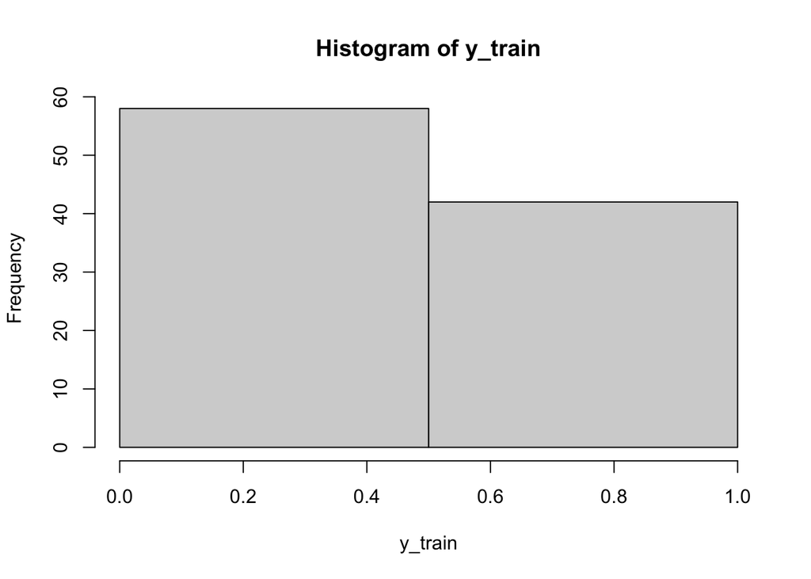

```r
# plot the distribution
hist(y_train, breaks = 2)
```

## Model Definition and Compilation

We define an RNN model with an embedding layer and LSTM layer:

```r
model <- keras_model_sequential() %>%
  layer_embedding(input_dim = 10000, output_dim = 128) %>%
  layer_lstm(units = 64) %>%
  layer_dense(units = 1, activation = "sigmoid")

model %>% compile(
  loss = "binary_crossentropy",
  optimizer = "adam",
  metrics = c("accuracy")
)
```

## Model Training

We train the model for 20 epochs with a batch size of 100 samples.

```r
model %>% fit(
  x_train, y_train,
  epochs = 20,
  batch_size = 100,
  validation_data = list(x_val, y_val)
)
```

```
## 1/1 - 5s - loss: 0.6934 - accuracy: 0.5500 - val_loss: 0.6928 - val_accuracy: 0.5155 - 5s/epoch - 5s/step
## 1/1 - 4s - loss: 0.6885 - accuracy: 0.6600 - val_loss: 0.6927 - val_accuracy: 0.5057 - 4s/epoch - 4s/step
## 1/1 - 4s - loss: 0.6834 - accuracy: 0.6300 - val_loss: 0.6925 - val_accuracy: 0.5033 - 4s/epoch - 4s/step
## 1/1 - 3s - loss: 0.6778 - accuracy: 0.6100 - val_loss: 0.6925 - val_accuracy: 0.5030 - 3s/epoch - 3s/step
## 1/1 - 3s - loss: 0.6712 - accuracy: 0.6100 - val_loss: 0.6926 - val_accuracy: 0.5028 - 3s/epoch - 3s/step
## 1/1 - 3s - loss: 0.6635 - accuracy: 0.6000 - val_loss: 0.6929 - val_accuracy: 0.5028 - 3s/epoch - 3s/step
## 1/1 - 4s - loss: 0.6543 - accuracy: 0.5900 - val_loss: 0.6935 - val_accuracy: 0.5028 - 4s/epoch - 4s/step
## 1/1 - 3s - loss: 0.6432 - accuracy: 0.5800 - val_loss: 0.6949 - val_accuracy: 0.5028 - 3s/epoch - 3s/step
## 1/1 - 3s - loss: 0.6299 - accuracy: 0.5800 - val_loss: 0.6976 - val_accuracy: 0.5027 - 3s/epoch - 3s/step
## 1/1 - 3s - loss: 0.6140 - accuracy: 0.5800 - val_loss: 0.7029 - val_accuracy: 0.5027 - 3s/epoch - 3s/step
## 1/1 - 4s - loss: 0.5951 - accuracy: 0.5800 - val_loss: 0.7134 - val_accuracy: 0.5027 - 4s/epoch - 4s/step
## 1/1 - 4s - loss: 0.5735 - accuracy: 0.5800 - val_loss: 0.7356 - val_accuracy: 0.5027 - 4s/epoch - 4s/step
## 1/1 - 3s - loss: 0.5517 - accuracy: 0.5800 - val_loss: 0.7627 - val_accuracy: 0.5027 - 3s/epoch - 3s/step
## 1/1 - 4s - loss: 0.5310 - accuracy: 0.5800 - val_loss: 0.7494 - val_accuracy: 0.5028 - 4s/epoch - 4s/step
## 1/1 - 3s - loss: 0.4950 - accuracy: 0.6100 - val_loss: 0.7279 - val_accuracy: 0.5030 - 3s/epoch - 3s/step
## 1/1 - 3s - loss: 0.4588 - accuracy: 0.7400 - val_loss: 0.7153 - val_accuracy: 0.5067 - 3s/epoch - 3s/step
## 1/1 - 3s - loss: 0.4229 - accuracy: 0.8400 - val_loss: 0.7118 - val_accuracy: 0.5129 - 3s/epoch - 3s/step
## 1/1 - 4s - loss: 0.3779 - accuracy: 0.8700 - val_loss: 0.7268 - val_accuracy: 0.5198 - 4s/epoch - 4s/step
## 1/1 - 4s - loss: 0.3201 - accuracy: 0.9100 - val_loss: 0.8504 - val_accuracy: 0.5252 - 4s/epoch - 4s/step
## 1/1 - 4s - loss: 0.2812 - accuracy: 0.9200 - val_loss: 0.7161 - val_accuracy: 0.5608 - 4s/epoch - 4s/step
```

## Model Evaluation

We evaluate the model on the test set:

```r
loss_and_metrics <- model %>% evaluate(x_test, imdb$test$y, batch_size = 32)
```

```
## 782/782 - 9s - loss: 0.7159 - accuracy: 0.5596 - 9s/epoch - 12ms/step
```

```r
cat("Test Loss:", loss_and_metrics[[1]], "\n")
```

```
## Test Loss: 0.715899
```

```r
cat("Test Accuracy:", loss_and_metrics[[2]], "\n")
```

```
## Test Accuracy: 0.55964
```

## Conclusion

We have successfully trained and evaluated an RNN model for sentiment analysis on the IMDB dataset with the specified modifications. Further experiments can be conducted to explore the impact of using pre-trained word embeddings and varying the number of training samples on model performance.